# Computer Vision Project

## Part A

Company X owns a movie application and repository which caters movie streaming to millions of users who on subscription basis. Company wants to automate the process of cast and crew information in each scene from a movie such that when a user pauses on the movie and clicks on cast information button, the app will show details of the actor in the scene. Company has an in-house computer vision and multimedia experts who need to detect faces from screen shots from the movie scene.

**Importing modules for project**

```python
import numpy as np
import pandas as pd
import matplotlib.pyplot as plt
import cv2, warnings, os, pickle, datetime, zipfile, re
from PIL import Image
from tqdm import tqdm
warnings.filterwarnings("ignore")


from tensorflow.keras.applications.mobilenet import MobileNet
from tensorflow.keras.applications.mobilenet import preprocess_input
from tensorflow.keras.layers import Concatenate, Conv2D, Reshape, UpSampling2D, Convolution2DTranspose
from tensorflow.keras.models import Sequential
from tensorflow.keras.layers import ZeroPadding2D, Convolution2D, MaxPooling2D, Dropout, Flatten, Activation
from tensorflow.keras.models import Model
from tensorflow.keras.utils import plot_model
from tensorflow.keras import optimizers, regularizers
from tensorboard.plugins.hparams import api as hp
from tensorflow.keras.models import load_model
from tensorflow.keras import backend
import tensorflow as tf


from sklearn.preprocessing import StandardScaler
from sklearn.model_selection import train_test_split
from sklearn.svm import SVC
from sklearn.decomposition import PCA
from sklearn.preprocessing import LabelEncoder
```

```python
from google.colab import drive #mounting drive
drive.mount('/content/drive')
```

**Import and read ‘images.npy’.**

```python
images = np.load('drive/My Drive/Colab Notebooks/com vis 2/images.npy', allow_pickle=True)
```

```python
images[0][0]
```

```
array([[[42, 37, 34],
        [56, 51, 48],
        [71, 66, 63],
        ...,
        [23, 33, 34],
        [26, 36, 37],
        [28, 38, 39]],

       [[40, 35, 32],
        [51, 46, 43],
        [64, 59, 56],
        ...,
        [27, 36, 35],
        [24, 33, 32],
        [26, 35, 34]],

       [[43, 38, 35],
        [51, 46, 43],
        [61, 56, 53],
        ...,
        [28, 30, 27],
        [33, 35, 32],
        [35, 37, 34]],

       ...,

       [[56, 47, 40],
        [57, 48, 41],
        [61, 52, 45],
        ...,
        [67, 48, 42],
        [55, 35, 28],
        [60, 40, 33]],

       [[53, 44, 37],
        [54, 45, 38],
        [57, 48, 41],
        ...,
        [59, 40, 34],
        [60, 40, 33],
        [54, 34, 27]],

       [[53, 44, 37],
        [54, 45, 38],
        [57, 48, 41],
        ...,
        [59, 40, 34],
        [70, 50, 43],
        [64, 44, 37]]], dtype=uint8)
```

```python
# lets create function to display dimensions to study from the image dataset
def imsize(images):

    dh=[]
    dw=[]
    dc=[]
    ds=[]

    for i in images:
        try:
            (h,w,c)=i.shape
        except:
            (h,w)=i.shape
            c=1
        dh.append(h)
        dw.append(w)
        dc.append(c)
        ds.append(len(i.shape))

    minh = min(dh)
    minw = min(dw)
    minc = min(dc)
    mins = min(ds)

    maxh = max(dh)
    maxw = max(dw)
    maxc = max(dc)
    maxs = max(ds)

    # display the dimension limits
    print((minh,minw,minc,maxs,maxh,maxw,maxc,maxs))

    return dh,dw,dc,ds
```

```python
# review the dimensions of the images
dh,dw,dc,ds = imsize(images[:,0])
```

```
(180, 182, 1, 3, 4016, 6016, 4, 3)
```

the image size ranges from 180 to 6016 pixels in either directions it could be seen that there are single channel images as well as 4 channel images

```python
# split the images and labels
# also standardise the number of channels in each image
img = []
lab = []
msk = []
n4s = []
for n,[i,l] in enumerate(images):
    # check channels
    try:
        h,w,c = i.shape
    except: # single channel images
        h,w = i.shape
        nimg = np.zeros((h,w,3),dtype='uint8') # create 3 channels
        nimg[:,:,0] = i
        nimg[:,:,1] = i
        nimg[:,:,2] = i
        i = nimg
        h,w,c = i.shape
    if c!=3: # if number of channels more than 3
        n4s.append(n)

    # append images & labels
    img.append(i)
    lab.append(l)

    # create masked images
    mask = np.zeros((h,w),dtype='uint8')
    for box in l:
        a,b = np.multiply(list(box.get('points')[0].values()),[w,h]).astype(int)
        c,d = np.multiply(list(box.get('points')[1].values()),[w,h]).astype(int)
        cv2.rectangle(mask,(a,b),(c,d), 1, -1)

    # append masked images
    msk.append(mask)
# verify if there are images with channels more than 3
print(len(n4s))
```

```
11
```

```python
# review 4th channels of those images
for i in n4s:
    print(i,img[i].shape, np.unique(img[i][:,:,3]))
```

```
1 (697, 1280, 4) [255]
3 (291, 600, 4) [255]
41 (340, 516, 4) [255]
49 (600, 800, 4) [255]
64 (312, 750, 4) [255]
140 (330, 538, 4) [255]
151 (496, 860, 4) [  0   2   4   6   8  10  12  14  16  18  20  22  23  25  27  29  31  33
  35  37  38  40  42  44  46  48  49  51  53  55  56  58  60  62  63  65
  67  69  70  72  74  75  77  79  80  82  84  85  87  89  90  92  93  95
  97  98 100 255]
247 (379, 505, 4) [255]
263 (400, 770, 4) [255]
337 (267, 740, 4) [255]
347 (281, 600, 4) [255]
```

almost every 4th channel is a plain white pixel, lets drop the same except for image 151, which contains certain other gray levels, lets review image 151

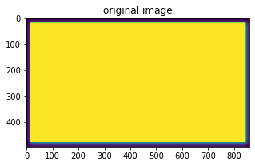

```python
# review the image 151 to verify
plt.figure(figsize=(5,5))
plt.title("original image")
plt.imshow(img[151][:,:,3])
```

the 4th channel in image 151 is a bounding box for the entire frame, which could also be droppped without affecting the quality of the image in other 3 channels

```python
# delete 4th channel in those images
for i in n4s:
    h,w,c = img[i].shape
    nimg = np.zeros((h,w,3),dtype='uint8') # create 3 channels
    nimg[:,:,0] = img[i][:,:,0]
    nimg[:,:,1] = img[i][:,:,1]
    nimg[:,:,2] = img[i][:,:,2]
    img[i] = nimg
```

**Split the data into Features(X) & labels(Y). Unify shape of all the images.**

```python
# review & store the dimensions limits before resizing
original_dims = imsize(img)
```

```
(180, 182, 3, 3, 4016, 6016, 3, 3)
```

[figure not shown]

```python
# preview a random image
np.random.seed(185)
ind = np.random.randint(0,409)
plt.figure(figsize=(15,45))
plt.subplot(131)
plt.title("original image")
plt.imshow(img[ind])
plt.subplot(132)
plt.title("mask")
plt.imshow(msk[ind])
plt.subplot(133)
plt.title("masked image")
masked = cv2.bitwise_and(img[ind],img[ind],mask=msk[ind])
plt.imshow(masked)
```

[figure not shown]

```python
# preview the image before & after resizing
plt.figure(figsize=(10,20))
plt.subplot(121)
plt.title("original image")
plt.imshow(img[ind])
plt.subplot(122)
plt.title("resized image")
plt.imshow(cv2.resize(img[ind],(128,128)))
```

```python
# Unify shape of all the images
# choosing 160 to suit MobileNet row recommended size
rimg = np.zeros_like(img)
rmsk = np.zeros_like(msk)
for i in range(409):
    xi = cv2.resize(img[i],(128,128)) # images
    rimg[i] = preprocess_input(np.array(xi, dtype=np.float32))

    rmsk[i] = cv2.resize(msk[i],(128,128)) # masks/bounding boxes
    rmsk[i] = (rmsk[i][:,:]>0.25)*1.0 # binary mask of float dtype
# review & store the dimensions limits after resizing
resized_dims = imsize(rimg)
```

```
(128, 128, 3, 3, 128, 128, 3, 3)
```

**Split the data into train and test[400:9].**

```python
# split train & test
np.random.seed(129)
indices = np.random.choice(range(409),(9,9),replace=False) # train:validation:test::328:72:9
test_index = indices[0]
validation_index = np.unique(indices[1:])
train_images = []
train_masks = []
val_images = []
val_masks = []
test_images = []
test_masks = []
for i in range(409): # split
    if i in test_index:
        test_images.append(rimg[i])
        test_masks.append(rmsk[i])
    elif i in validation_index:
        val_images.append(rimg[i])
        val_masks.append(rmsk[i])
    else:
        train_images.append(rimg[i])
        train_masks.append(rmsk[i])

train_images = np.array(train_images)
train_masks = np.array(train_masks)
val_images = np.array(val_images)
val_masks = np.array(val_masks)
test_images = np.array(test_images)
test_masks = np.array(test_masks)
```

**Select random image from the train data and display original image and masked image.**

```
WARNING:matplotlib.image:Clipping input data to the valid range for imshow with RGB data ([0..1] for floats or [0..255] for integers).
WARNING:matplotlib.image:Clipping input data to the valid range for imshow with RGB data ([0..1] for floats or [0..255] for integers).
```

[figure not shown]

```python
# preview a random training image
np.random.seed(11)
ind = np.random.randint(0,400)
plt.figure(figsize=(15,45))
plt.subplot(131)
plt.title("resized image")
plt.imshow(train_images[ind])
plt.subplot(132)
plt.title("mask")
plt.imshow(train_masks[ind])
plt.subplot(133)
plt.title("masked image")
masked = cv2.bitwise_and(train_images[ind],train_images[ind],mask=train_masks[ind].astype('uint8'))
plt.imshow(masked)
```

**Model building**

A. Design a face mask detection model.

B. Design your own Dice Coefficient and Loss function.

C. Train and tune the model as required.

D. Evaluate and share insights on performance of the model.

```python
def dice(y,pred):
    return 2 * tf.reduce_sum(pred*y)/(tf.reduce_sum(pred+y)+1) #+1 as epsilon
```

```python
# test the dice coefficient function
print("same mask dice coeff: %.3f"%dice(train_masks[ind],train_masks[ind]).numpy())
print("2 diff mask dice coeff: %.3f"%dice(train_masks[ind],train_masks[ind+8]).numpy())
```

```
same mask dice coeff: 1.000
2 diff mask dice coeff: 0.212
```

same masks dice coefficient is slightly less than 1 due to +1 in the denominator

```python
def loss(y,pred):
    # cross entropy loss for classification
    l1 = tf.keras.losses.binary_crossentropy(y,pred)
    # log loss(negative) from dice coeficient
    l2 = -tf.keras.backend.log(dice(y,pred)+1e-37) #1e-37 as epsilon
    return l1+l2
```

```python
# test the loss function
print("same mask loss levels:\n",np.unique(loss(train_masks[ind].astype(float),train_masks[ind].astype(float)).numpy()))
print("2 diff mask loss levels:\n",np.unique(loss(train_masks[ind].astype(float),train_masks[ind+8].astype(float)).numpy()))
```

```
same mask loss levels:
 [0.00016468]
2 diff mask loss levels:
 [1.55095896 3.84059975 4.20212198 5.40719608 5.76871831 6.853285  ]
```

```python
# lets define a method to create the Unet architecture
def MobileUNET(params={}):
    """method to create MobileNet base Unet analogous neural topology"""
    # read parameters
    alpha,train_from,upConvFilter = list(params.values())[:3]

    # Random consistency seed
    np.random.seed(129)
    tf.random.set_seed(129)

    # define MobileNet as the skeleton for this Unet alias attempt
    model = MobileNet(input_shape=(128,128,3),include_top=False,alpha=alpha,weights='imagenet')

    # fetch skip connections for feature mapping
    skip1 = model.get_layer('conv_pw_1_relu').output
    skip2 = model.get_layer('conv_pw_3_relu').output
    skip3 = model.get_layer('conv_pw_5_relu').output
    skip4 = model.get_layer('conv_pw_11_relu').output

    # name & identitfy the bottle neck output
    bottleNeck = model.get_layer('conv_pw_13_relu').output

    # transposed convolutions and concatenations to upsample from bottleneck
    build4 = Convolution2DTranspose(upConvFilter,kernel_size=(3,3),strides=(2,2),
                                    padding='same',name='build_conv_4')(bottleNeck)
    cat4 = Concatenate(name='build_cat_4')([build4,skip4])
    build3 = Convolution2DTranspose(upConvFilter,kernel_size=(3,3),strides=(2,2),
                                    padding='same',name='build_conv_3')(cat4)
    cat3 = Concatenate(name='build_cat_3')([build3,skip3])
    build2 = Convolution2DTranspose(upConvFilter,kernel_size=(3,3),strides=(2,2),
                                    padding='same',name='build_conv_2')(cat3)
    cat2 = Concatenate(name='build_cat_2')([build2,skip2])
    build1 = Convolution2DTranspose(upConvFilter,kernel_size=(3,3),strides=(2,2),
                                    padding='same',name='build_conv_1')(cat2)
    cat1 = Concatenate(name='build_cat_1')([build1,skip1])

    build0 = Convolution2DTranspose(upConvFilter,kernel_size=(3,3),strides=(2,2),
                                    padding='same',name='build_conv_0')(cat1)

    # introduce a convolutional layer with sigmoid function to obtain the desired mask with 0~1
    conv_mask = Conv2D(1,kernel_size=1,activation='sigmoid',name='mask_generator')(build0) #(transConv)

    # reshape to desired shape
    mask_layer = Reshape((128,128),name='output')(conv_mask)

    model = Model(inputs = model.input, outputs = mask_layer)

    for l in model.layers[:train_from]:
        l.trainable=False

    return model
```

```python
# lets train a base model
param = dict(alpha=1,train_from=9,channels=4,learningRate=0.001,upConvFilter=64)
model = MobileUNET(param)
model.compile(loss=loss,metrics=[dice])
# create tensorboard logs & callbacks
logdir = "logs"
tensorboard = tf.keras.callbacks.TensorBoard(logdir, histogram_freq=1)

# Random consistency seed
np.random.seed(129)
tf.random.set_seed(129)

with tf.device('/device:GPU:0'):
    logger = model.fit(x=train_images,y=train_masks,epochs=50,
                       validation_data=(val_images,val_masks),callbacks=[tensorboard])
```

```python
eval_result = model.evaluate(x=val_images, y=val_masks)
dict(zip(model.metrics_names,eval_result))
```

```
{'loss': 0.8053250312805176, 'dice': 0.668876588344574}
```

```python
# predict for test images
pred_masks = model.predict(x=test_images)
pred_masks = (pred_masks>0.5)
```

loss is 0.80 which is good. dice has 66% oveerlap.

**Test the model predictions on the test image: ‘image with index 3 in the test data’ and visualise the predicted masks on the faces in the image.**

```
WARNING:matplotlib.image:Clipping input data to the valid range for imshow with RGB data ([0..1] for floats or [0..255] for integers).
WARNING:matplotlib.image:Clipping input data to the valid range for imshow with RGB data ([0..1] for floats or [0..255] for integers).
WARNING:matplotlib.image:Clipping input data to the valid range for imshow with RGB data ([0..1] for floats or [0..255] for integers).
```

[figure not shown]

```python
plt.figure(figsize=(20,50))
plt.subplot(131)
plt.title("test image ")
trueImage = test_images[3]
plt.imshow(trueImage)
plt.subplot(132)
plt.title("test image masked")
masked = cv2.bitwise_and(trueImage,trueImage,mask=test_masks[3].astype('uint8'))
#cv2.bitwise_and(train_images[ind],train_images[ind],mask=train_masks[ind].astype('uint8'))
plt.imshow(masked)
plt.subplot(133)
plt.title("test image with predicted mask image")
masked = cv2.bitwise_and(trueImage,trueImage,mask=pred_masks[3].astype('uint8'))
plt.imshow(masked)
```

## Part B

Company X owns a movie application and repository which caters movie streaming to millions of users who on subscription basis. Company wants to automate the process of cast and crew information in each scene from a movie such that when a user pauses on the movie and clicks on cast information button, the app will show details of the actor in the scene. Company has an in-house computer vision and multimedia experts who need to detect faces from screen shots from the movie scene.

```python
# read image names and extract the contents of the zip file
with zipfile.ZipFile('drive/My Drive/Colab Notebooks/com vis 2/training_images.zip', 'r') as zfile:
    fnames = zfile.filelist
    zfile.extractall('.')
fnames = [f.filename for f in fnames]
```

**Write a loop which will iterate through all the images in the ‘training_images’ folder and detect the faces present on all the images.**

```python
# using haarcascade
face_cascade = cv2.CascadeClassifier('drive/My Drive/Colab Notebooks/com vis 2/haarcascade_frontalface_default.xml')

# detect face bounding boxes
metaArray = []
for i,file in enumerate(fnames): # loop to iterate through all images in folder
    face_image = np.array(Image.open(file)) # read image
    gray = cv2.cvtColor(face_image, cv2.COLOR_BGR2GRAY) # convert 3 channel rgb image to grayscale image
    faces = face_cascade.detectMultiScale(gray) # detect the bounding boxes for faces in the grayscale image
    face_count=len(faces)
    for n,(x, y, w, h) in enumerate(faces):
        metadata = [x,y,w,h,n+1,face_count,file.split('/')[-1]]
        metaArray.append(metadata)
```

**From the same loop above, extract metadata of the faces and write into a DataFrame.**

```python
metaDf = pd.DataFrame(metaArray,columns=['x','y','w','h','nth face','total faces','image name'])
display(metaDf.head())
```

|  | x | y | w | h | nth face | total faces | image name |
| --- | --- | --- | --- | --- | --- | --- | --- |
| 0 | 523 | 139 | 64 | 64 | 1 | 1 | real_00947.jpg |
| 1 | 339 | 412 | 128 | 128 | 1 | 1 | real_01052.jpg |
| 2 | 40 | 130 | 407 | 407 | 1 | 2 | real_01042.jpg |
| 3 | 431 | 267 | 156 | 156 | 2 | 2 | real_01042.jpg |
| 4 | 57 | 113 | 447 | 447 | 1 | 1 | real_00964.jpg |

**Save the output Dataframe in .csv format**

```python
metaDf.to_csv('drive/My Drive/Colab Notebooks/com vis 2/metadata.csv',index=False)
```

## Part C

DOMAIN: Face Recognition

CONTEXT: Company X intends to build a face identification model to recognise human faces.

DATA DESCRIPTION: The dataset comprises of images and its mask where there is a human face.

PROJECT OBJECTIVE: Face Aligned Face Dataset from Pinterest. This dataset contains 10,770 images for 100 people. All images are taken from 'Pinterest' and aligned using dlib library.

**Unzip, read and Load data(‘PINS.zip’) into session**

```python
# extract the PINS zip file
with zipfile.ZipFile('drive/My Drive/Colab Notebooks/com vis 2/PINS.zip','r') as zfile:
    zfile.extractall('.') # extract
    flist = zfile.filelist # fetch files list

# extract file paths
fnames = []
for file in flist:
    name = file.filename # retreive file name
    if name.startswith('__MACOSX'): # ignore MAC OS specific files
        continue
    if name.endswith('/'): # ignore folder paths
        continue
    fnames.append(name) # store image paths
```

**Write function to create metadata of the image.**

```python
def meta(fpath):
    """returns dictionary of metadata"""
    name = re.split(r'pins_|[//]',fpath)[2]
    return dict(name=name,path=fpath)
```

```python
# test the meta function
meta(fnames[1000])
```

```
{'name': 'Emilia Clarke',
 'path': 'PINS/pins_Emilia Clarke/Emilia Clarke2_1022.jpg'}
```

**Write a loop to iterate through each and every image and create metadata for all the images.**

```python
# loop and create meta data for all images
metaArray = []
for fpath in fnames:
    metaArray.append(meta(fpath))
```

```python
# display few from metaArray
for ind in np.random.randint(0,len(metaArray),(5)):
    print(metaArray[ind])
```

```
{'name': 'elon musk', 'path': 'PINS/pins_elon musk/elon musk6.jpg'}
{'name': 'Robin Taylor', 'path': 'PINS/pins_Robin Taylor/Robin Taylor71.jpg'}
{'name': 'kiernan shipka ', 'path': 'PINS/pins_kiernan shipka /kiernan shipka 62.jpg'}
{'name': 'anne hathaway', 'path': 'PINS/pins_anne hathaway/anne hathaway70.jpg'}
{'name': 'Dwayne Johnson', 'path': 'PINS/pins_Dwayne Johnson/Dwayne Johnson7.jpg'}
```

**Generate Embeddings vectors on the each face in the dataset.**

```python
 #define vgg face model topology
def vgg_face():
    model = Sequential()
    model.add(ZeroPadding2D((1,1),input_shape=(224,224, 3)))
    model.add(Convolution2D(64, (3, 3), activation='relu'))
    model.add(ZeroPadding2D((1,1)))
    model.add(Convolution2D(64, (3, 3), activation='relu'))
    model.add(MaxPooling2D((2,2), strides=(2,2)))

    model.add(ZeroPadding2D((1,1)))
    model.add(Convolution2D(128, (3, 3), activation='relu'))
    model.add(ZeroPadding2D((1,1)))
    model.add(Convolution2D(128, (3, 3), activation='relu'))
    model.add(MaxPooling2D((2,2), strides=(2,2)))

    model.add(ZeroPadding2D((1,1)))
    model.add(Convolution2D(256, (3, 3), activation='relu'))
    model.add(ZeroPadding2D((1,1)))
    model.add(Convolution2D(256, (3, 3), activation='relu'))
    model.add(ZeroPadding2D((1,1)))
    model.add(Convolution2D(256, (3, 3), activation='relu'))
    model.add(MaxPooling2D((2,2), strides=(2,2)))

    model.add(ZeroPadding2D((1,1)))
    model.add(Convolution2D(512, (3, 3), activation='relu'))
    model.add(ZeroPadding2D((1,1)))
    model.add(Convolution2D(512, (3, 3), activation='relu'))
    model.add(ZeroPadding2D((1,1)))
    model.add(Convolution2D(512, (3, 3), activation='relu'))
    model.add(MaxPooling2D((2,2), strides=(2,2)))

    model.add(ZeroPadding2D((1,1)))
    model.add(Convolution2D(512, (3, 3), activation='relu'))
    model.add(ZeroPadding2D((1,1)))
    model.add(Convolution2D(512, (3, 3), activation='relu'))
    model.add(ZeroPadding2D((1,1)))
    model.add(Convolution2D(512, (3, 3), activation='relu'))
    model.add(MaxPooling2D((2,2), strides=(2,2)))

    model.add(Convolution2D(4096, (7, 7), activation='relu'))
    model.add(Dropout(0.5))
    model.add(Convolution2D(4096, (1, 1), activation='relu'))
    model.add(Dropout(0.5))
    model.add(Convolution2D(2622, (1, 1)))
    model.add(Flatten())
    model.add(Activation('softmax'))
    return model
```

```python
# instantiate the model
vggFace = vgg_face()

# load trained weights
vggFace.load_weights('drive/My Drive/Colab Notebooks/com vis 2/vgg_face_weights.h5')

# trim out a submodel from vggFace to extract just embeddings, not the classification
faceEmbed = Model(inputs=vggFace.layers[0].input, outputs=vggFace.layers[-2].output)
```

```python
# generate embeddings for one image
face = np.array(Image.open(metaArray[0].get('path'))) # read image
face = (face/255.0).astype(np.float32) # normalise image
face = cv2.resize(face,(224,224)) # resize to suit vgg_face model
embedding = faceEmbed.predict(np.expand_dims(face,0))[0] # predict embeddings
embedding.shape # review embedding shape
```

```
(2622,)
```

```python
# loop over all images
def embed(img):
    face = np.array(Image.open(img.get('path')))
    face = (face/255.0).astype(np.float32)
    face = cv2.resize(face,(224,224))
    embedding = faceEmbed.predict(np.expand_dims(face,0))[0]
    img.update(dict(embedding = embedding))
```

```python
%%time
for img in tqdm(metaArray):
    embed(img)
```

```
CPU times: user 19min 17s, sys: 28.5 s, total: 19min 45s
Wall time: 27min 5s
```

**Build distance metrics for identifying the distance between two similar and dissimilar images.**

```python
# define distance metric
def distance(embA,embB):
    return np.sum(np.square(embA-embB))
```

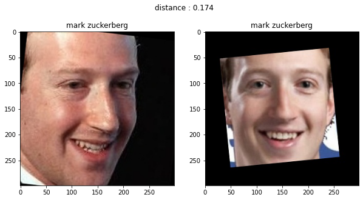

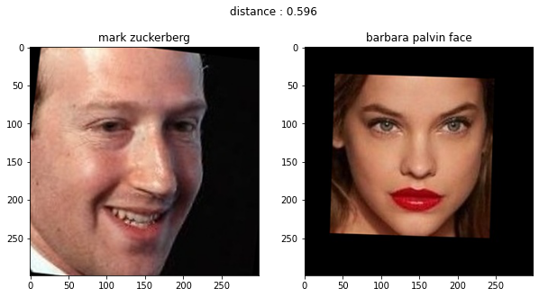

```python
def compareImage(a,b):
    img1 = Image.open(metaArray[a].get('path'))
    img2 = Image.open(metaArray[b].get('path'))
    name1 = metaArray[a].get('name')
    name2 = metaArray[b].get('name')
    embA = metaArray[a].get('embedding')
    embB = metaArray[b].get('embedding')
    dist = distance(embA,embB)
    plt.figure(figsize=(10,5))
    plt.suptitle('distance : %.3f'%dist)
    plt.subplot(121)
    plt.title(name1)
    plt.imshow(img1)
    plt.subplot(122)
    plt.title(name2)
    plt.imshow(img2)
# lets test the distance measures
compareImage(40,41)
compareImage(40,401)
```

**Use PCA for dimensionality reduction**

```python
# stack a numpy array of embeddings as the independant variable
# list the respective names as target class
X = np.array([m.get('embedding') for m in metaArray])
Y = np.array([m.get('name') for m in metaArray])
```

```python
# split train & test datasets
X_train, X_test, Y_train, Y_test = train_test_split(X, Y,test_size=0.10, # split ratio of 90:10
                                                    random_state=129) # random seed
```

```python
# standardize
scl=StandardScaler()
X_train = scl.fit_transform(X_train)
X_test = scl.transform(X_test) # transform only
```

```python
# apply PCA with 20 components
pca = PCA(n_components=20)
pca.fit(X_train);
exp_var=np.cumsum(pca.explained_variance_ratio_)
```

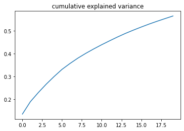

```python
plt.figure()
plt.title('cumulative explained variance')
plt.plot(exp_var);
```

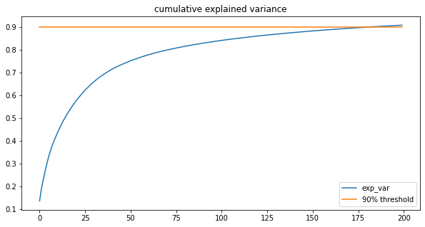

```python
# apply PCA with more components
pca = PCA(n_components=200)
pca.fit(X_train);

# calculate explained variance cumulative summation
exp_var=np.cumsum(pca.explained_variance_ratio_)

# visualise
plt.figure(figsize=(10,5))
plt.title('cumulative explained variance')
plt.plot(exp_var,label='exp_var')
plt.plot(np.ones(len(exp_var))*0.9,label='90% threshold')
plt.legend()
plt.show()
```

```python
for i,evar in enumerate(exp_var):
    if evar>=0.9:
        print("nComponets: %d"%i, " cum_var: %.3f"%evar)
        break
```

```
nComponets: 181  cum_var: 0.900
```

the cummulative explained variance reaches 90% for 181 components lets build again the PCA for 181 components and proceed further

```python
# apply PCA with 181 components
pca = PCA(n_components=181)
X_train = pca.fit_transform(X_train)
X_test = pca.transform(X_test)
```

**Build an SVM classifier in order to map each image to its right person.**

```python
# encode target variables
le = LabelEncoder()
Y_train = le.fit_transform(Y_train)
Y_test = le.transform(Y_test)
```

```python
# confirm shapes all variables
X_train.shape, Y_train.shape, X_test.shape, Y_test.shape
```

```
((9693, 181), (9693,), (1077, 181), (1077,))
```

```python
# build a SVC for the above dataset
classifer = SVC()
classifer.fit(X_train,Y_train) #fit
print("accuracy score: %.6f"%classifer.score(X_test,Y_test))
```

```
accuracy score: 0.951718
```

**Import and display the the test images.**

**Use the trained SVM model to predict the face on both test images.**

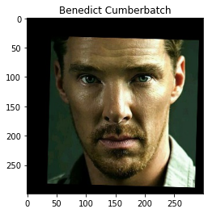

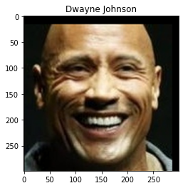

```python
test_images = ['drive/My Drive/Colab Notebooks/com vis 2/Benedict Cumberbatch9.jpg','drive/My Drive/Colab Notebooks/com vis 2/Dwayne Johnson4.jpg']
for test in test_images:
    face = np.array(Image.open(test))
    face2 = (face/255.0).astype(np.float32)
    face2 = cv2.resize(face2,(224,224))
    embedding = faceEmbed.predict(np.expand_dims(face2,0))
    test_emb = scl.transform(embedding)
    test_emb = pca.transform(test_emb)
    prediction = classifer.predict(test_emb)
    prediction = le.inverse_transform(prediction)
    plt.figure()
    plt.title(prediction[0])
    plt.imshow(face)
```